# 1. Volatility Modeling and Its Application with Python

## Abdullah Karasan

Due to increased integrations and complex and deepening financial operations, the financial markets have a high level of uncertainty, which should be understood and modeled to gain insight about what is going on in the market. Uncertainty comes in the form of volatility, which, in turn, amounts to information. To this end, determining the causes of volatility in financial markets and predicting these movements beforehand have become an indispensable condition of financial success in these markets.

Besides, volatility and risk go in tandem in financial markets. Increasing risk emanating from volatility poses a huge threat to investment decisions. So, it is not adequate to know the current volatility in the market, investors should have knowledge about the likely future path of volatility as well. Only after that, can an investor properly gauge the market dynamics and risk level, which enables her to invest in a well-founded way.

Despite its theoretical appeal and intuitiveness, some of the main assumptions of financial modeling have been attacked by certain researchers. As it is empirically shown, asset returns do not conform to the assumptions of random walk theorem such as constant variance and independence. Besides, linear models are not able to capture the main characteristics of financial variables, which are:

- Leptokurtosis: By and large, financial variables show fat tail and excess peakedness, which is a deviation from normal distribution.
- Volatility Clustering: In financial markets, volatilities co-move. That is to say, a high volatility is followed by another high volatility or vice versa.
- Leverage: Empirical studies suggest that there is an asymmetry in volatility, meaning that volatility in high price drops can generate higher volatility than a price increase can.

In this lesson, we will study some well-known volatility models:

- `ARCH`,
- `GARCH`, and
- `EGARCH`

Then, we will conduct prediction analyses based on them.

# 2. Volatility Prediction based on ARCH model

In order to take into account all these deviations (i.e., leptokurtosis, volatility clustering, and leverage), the `ARCH` (Autoregressive Conditional Heteroscedasticity) model by Engle (1982) and Bollerslev (1986), has been proposed. Mathematically speaking:

$$ \sigma^2_t=\alpha_0+\alpha_1u^2_{t-1}+\alpha_2u^2_{t-2}+\cdots...+\alpha_qu^2_{t-q}=\alpha_0+\sum_i^q\alpha_iu^2_{t-i} $$

where $\alpha_0>0, \alpha_i>0, \text{ and } u_t=\sigma_tz_t$

The steps we need to estimate the ARCH model are:

- Fitting autoregressive model to obtain $u_i$. $r_t=\alpha_0+\alpha_1r_{t-1}+\cdots...+\alpha_pr_{t-q}+u_t$
- After having $u^2$, regress them on a constant $\alpha$ and q lagged values of error terms

Let's model the volatility using the ARCH model in Python. We will employ four arbitrarily selected stocks:

- Ford Motor Company
- BlackRock Inc.
- Amazon.com Inc.
- Alphabet Inc. Class C (the company formerly known as Google)

```python
import pandas as pd
import numpy as np
import matplotlib.pyplot as plt
import datetime
import seaborn as sns
import yfinance as yf
```

Using Yahoo Finance, we retrieve daily stock prices of our four stocks for the period of `01-01-2010` and `01-04-2020`:

```python
stocks = ['F','BLK','GOOG','AMZN']
start = datetime.datetime(2010,1,1)
end = datetime.datetime(2020,4,1)
stock_prices = yf.download(stocks,start=start,end = end, interval='1d')['Adj Close']
```

```
[*********************100%***********************]  4 of 4 downloaded
```

```python
stock_prices.head()
```

| Date | AMZN | BLK | F | GOOG |
| --- | --- | --- | --- | --- |
| 2009-12-31 | 134.52 | 175.23 | 6.66 | 308.83 |
| 2010-01-04 | 133.90 | 180.04 | 6.85 | 312.20 |
| 2010-01-05 | 134.69 | 180.82 | 7.30 | 310.83 |
| 2010-01-06 | 132.25 | 177.09 | 7.57 | 302.99 |
| 2010-01-07 | 130.00 | 179.04 | 7.77 | 295.94 |

As we may notice, it is not stock price but return that we used as a variable in modeling volatility and, by convention, log return is embraced in the literature. As a final step, we scale returns up by 100 to get rid of convergence issues:

```python
returns_all=[]
for i in stock_prices.columns:
    log_returns=np.log(stock_prices[str(i)]/stock_prices[str(i)].shift(1))
    returns_all.append(100*log_returns)
```

Here, we turn list objects into a dataframe and transpose it to properly aligned rows and columns:

```python
returns_all=pd.DataFrame(returns_all)
returns_all=returns_all.T
```

```python
returns_all=pd.DataFrame(returns_all,columns=stock_prices.columns)
returns_all
```

| Date | AMZN | BLK | F | GOOG |
| --- | --- | --- | --- | --- |
| 2009-12-31 | NaN | NaN | NaN | NaN |
| 2010-01-04 | -0.461963 | 2.707965 | 2.812917 | 1.085304 |
| 2010-01-05 | 0.588259 | 0.432301 | 6.362570 | -0.439787 |
| 2010-01-06 | -1.828177 | -2.084398 | 3.631872 | -2.554634 |
| 2010-01-07 | -1.715962 | 1.095117 | 2.607710 | -2.354307 |
| ... | ... | ... | ... | ... |
| 2020-03-25 | -2.836617 | 7.682153 | 8.515781 | -2.858551 |
| 2020-03-26 | 3.626746 | 11.855231 | -2.631731 | 5.235623 |
| 2020-03-27 | -2.873429 | -3.963328 | -1.149438 | -4.492804 |
| 2020-03-30 | 3.305123 | 4.723872 | -3.131371 | 3.199344 |
| 2020-03-31 | -0.727198 | -3.435981 | -4.057352 | 1.384659 |

2579 rows × 4 columns

As a final step of the data preparation, we drop the `NaN` values that we see at the first row of the `returns_all` data. Then, we obtain summary statistics providing the very first assessment of the data:

```python
returns_all.dropna(inplace=True)
```

```python
returns_all.describe()
```

|  | AMZN | BLK | F | GOOG |
| --- | --- | --- | --- | --- |
| count | 2578.000000 | 2578.000000 | 2578.000000 | 2578.000000 |
| mean | 0.103713 | 0.035710 | -0.012462 | 0.051428 |
| std | 1.971059 | 1.751245 | 1.881573 | 1.603820 |
| min | -13.532540 | -14.681464 | -14.408437 | -11.766724 |
| 25% | -0.829912 | -0.749720 | -0.888238 | -0.652899 |
| 50% | 0.096986 | 0.041613 | 0.000000 | 0.048938 |
| 75% | 1.125613 | 0.918064 | 0.940888 | 0.850515 |
| max | 14.622537 | 12.684333 | 21.059634 | 14.887186 |

As expected, the visualization tells us that the returns of the stocks at our disposal fluctuate around zero, but it is not possible to state that we have constant volatility:

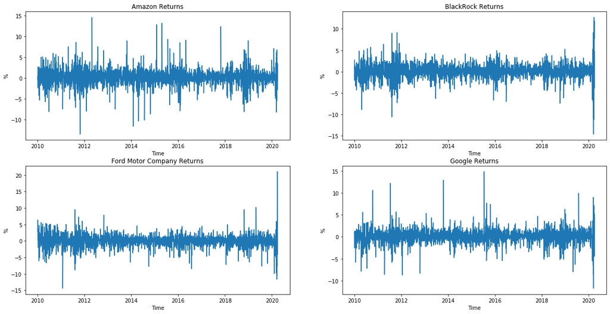

```python
plt.figure(figsize=(20,10))
plt.subplot(2,2,1)
plt.plot(returns_all['AMZN'])
plt.ylabel('%')
plt.title('Amazon Returns')
plt.xlabel('Time')
plt.subplot(2,2,2)
plt.plot(returns_all['BLK'])
plt.ylabel('%')
plt.title('BlackRock Returns')
plt.xlabel('Time')
plt.subplot(2,2,3)
plt.plot(returns_all['F'])
plt.ylabel('%')
plt.title('Ford Motor Company Returns')
plt.xlabel('Time')
plt.subplot(2,2,4)
plt.plot(returns_all['GOOG'])
plt.ylabel('%')
plt.title('Google Returns')
plt.xlabel('Time')
plt.show()
```

```python
from arch import arch_model
```

```python
results_arch=[]
for i in returns_all.columns:
    results_arch.append(arch_model((returns_all[i]),mean='Constant',vol='arch',dist='Normal').fit(disp='off'))
```

The result of the ARCH model is given below. `omega` and `alpha` are the constant term and slope coefficients, respectively. Based on this estimation, we conduct our prediction. In the prediction, we employ these estimated coefficients:

```python
results_arch
```

```
[                      Constant Mean - ARCH Model Results
 ==============================================================================
 Dep. Variable:                   AMZN   R-squared:                      -0.000
 Mean Model:             Constant Mean   Adj. R-squared:                 -0.000
 Vol Model:                       ARCH   Log-Likelihood:               -5343.96
 Distribution:                  Normal   AIC:                           10693.9
 Method:            Maximum Likelihood   BIC:                           10711.5
                                         No. Observations:                 2578
 Date:                Tue, May 19 2020   Df Residuals:                     2575
 Time:                        11:02:06   Df Model:                            3
                                 Mean Model
 ==========================================================================
                  coef    std err          t      P>|t|    95.0% Conf. Int.
 --------------------------------------------------------------------------
 mu             0.1366  3.715e-02      3.677  2.363e-04 [6.378e-02,  0.209]
                             Volatility Model
 ========================================================================
                  coef    std err          t      P>|t|  95.0% Conf. Int.
 ------------------------------------------------------------------------
 omega          3.0733      0.250     12.293  9.907e-35 [  2.583,  3.563]
 alpha[1]       0.2345  6.293e-02      3.726  1.944e-04 [  0.111,  0.358]
 ========================================================================

 Covariance estimator: robust
 ARCHModelResult, id: 0x1a28c74438,
                       Constant Mean - ARCH Model Results
 ==============================================================================
 Dep. Variable:                    BLK   R-squared:                      -0.000
 Mean Model:             Constant Mean   Adj. R-squared:                 -0.000
 Vol Model:                       ARCH   Log-Likelihood:               -4871.75
 Distribution:                  Normal   AIC:                           9749.51
 Method:            Maximum Likelihood   BIC:                           9767.07
                                         No. Observations:                 2578
 Date:                Tue, May 19 2020   Df Residuals:                     2575
 Time:                        11:02:06   Df Model:                            3
                                  Mean Model
 ===========================================================================
                  coef    std err          t      P>|t|     95.0% Conf. Int.
 ---------------------------------------------------------------------------
 mu             0.0543  3.040e-02      1.785  7.420e-02 [-5.306e-03,  0.114]
```

[output cut: 45 more lines]

```
                                 Mean Model
 ==========================================================================
                  coef    std err          t      P>|t|    95.0% Conf. Int.
 --------------------------------------------------------------------------
 mu             0.0800  3.761e-02      2.126  3.352e-02 [6.239e-03,  0.154]
                              Volatility Model
 ==========================================================================
                  coef    std err          t      P>|t|    95.0% Conf. Int.
 --------------------------------------------------------------------------
 omega          1.9607      0.164     11.958  5.914e-33   [  1.639,  2.282]
 alpha[1]       0.2684  9.230e-02      2.907  3.644e-03 [8.745e-02,  0.449]
 ==========================================================================

 Covariance estimator: robust
 ARCHModelResult, id: 0x1a28c32860]
```

```python
split_date='2019-02-01'
forecast_arch=[]
for i in range(len(returns_all.columns)):
    forecast_arch.append(results_arch[i].forecast(start=split_date).variance[split_date:].mean(axis=1))
```

```python
forecast_arch=pd.DataFrame(forecast_arch).T
```

```python
forecast_arch.columns=returns_all.columns
forecast_arch
```

| Date | AMZN | BLK | F | GOOG |
| --- | --- | --- | --- | --- |
| 2019-02-01 | 10.608649 | 1.998315 | 2.629607 | 2.052396 |
| 2019-02-04 | 3.094056 | 1.972320 | 2.390346 | 2.914977 |
| 2019-02-05 | 3.541176 | 1.963766 | 2.510095 | 2.272350 |
| 2019-02-06 | 3.446230 | 1.992288 | 2.416615 | 4.065803 |
| 2019-02-07 | 3.773127 | 2.004043 | 10.605875 | 2.624132 |
| ... | ... | ... | ... | ... |
| 2020-03-25 | 5.146202 | 20.595777 | 27.993959 | 4.277933 |
| 2020-03-26 | 5.929705 | 46.569338 | 4.795835 | 9.094017 |
| 2020-03-27 | 5.197850 | 7.127043 | 2.828741 | 7.572174 |
| 2020-03-30 | 5.427511 | 8.941540 | 5.808064 | 4.572005 |
| 2020-03-31 | 3.248221 | 5.858690 | 8.149505 | 2.417491 |

293 rows × 4 columns

To compare how good our prediction is we need a benchmark variable, which is `realized variance` in this case. Though there are different approaches, realized variance is computed here as a standard deviation of the returns. The standard deviation of the stock is computed in a way to include five subsequent returns in the calculated standard deviation. Then, a second five subsequent returns, and the next five, and so on. It is know as the `rolling` method and the number of subsequent returns are labeled as `window size`.

```python
window_size=5
rv_all=[]
for j in returns_all.columns:
    rv=(returns_all[j]).rolling(window_size).std()
    rv_all.append(rv)
rv_all=pd.DataFrame(rv_all).T
rv_all.dropna(inplace=True)
```

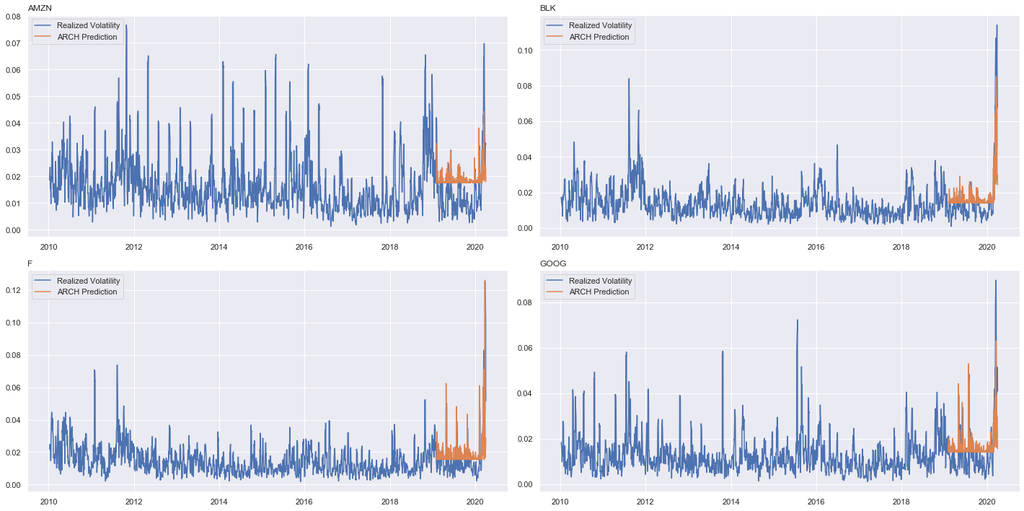

```python
sns.set()
plt.figure(figsize=(20,10))
k=0
for i,j in zip(returns_all.columns,range(len(returns_all.columns))):
    k+=1
    plt.subplot(2,2, k)
    plt.tight_layout()
    plt.plot(rv_all[i]/100,label='Realized Volatility')
    plt.plot(np.sqrt(forecast_arch.iloc[:,j])/100,label='ARCH Prediction')
    plt.title(i, loc='left', fontsize=12)
    plt.legend(loc='best')
```

# 3. Volatility Prediction Based on GARCH Model

Bollerslev (1986) and Taylor (2008) improved the ARCH model by adding lagged conditional variance into the equation and it is referred to as `GARCH` (The Generalized Autoregressive Conditional Heteroscedasticity). The mathematical equation is similar to ARCH except for one term, which is the past values of conditional volatility $\sigma^2$:

$$ \sigma^2_t=\omega+\beta\sigma^2_{t-1}+\alpha u^2_{t-1} $$

where $\omega$, $\beta$, and $\alpha$ are parameters and have restrictions: $\omega$ $>$ 0, $\beta$ $\geq$ 0, and $\alpha$ $\geq$ 0.

```python
from arch import arch_model
```

```python
results_garch=[]
for i in returns_all.columns:
    results_garch.append(arch_model((returns_all[i]),mean='Constant',vol='garch',dist='Normal').fit(disp='off'))
```

Different from the ARCH model, we have one more variable, $\beta$, attached to lagged values of conditional variance. The GARCH model result is exhibited below:

```python
results_garch
```

```
[                     Constant Mean - GARCH Model Results
 ==============================================================================
 Dep. Variable:                   AMZN   R-squared:                      -0.001
 Mean Model:             Constant Mean   Adj. R-squared:                 -0.001
 Vol Model:                      GARCH   Log-Likelihood:               -5288.09
 Distribution:                  Normal   AIC:                           10584.2
 Method:            Maximum Likelihood   BIC:                           10607.6
                                         No. Observations:                 2578
 Date:                Tue, May 19 2020   Df Residuals:                     2574
 Time:                        11:31:17   Df Model:                            4
                                 Mean Model
 ==========================================================================
                  coef    std err          t      P>|t|    95.0% Conf. Int.
 --------------------------------------------------------------------------
 mu             0.1613  3.704e-02      4.354  1.337e-05 [8.867e-02,  0.234]
                              Volatility Model
 ==========================================================================
                  coef    std err          t      P>|t|    95.0% Conf. Int.
 --------------------------------------------------------------------------
 omega          0.4245      0.145      2.924  3.456e-03   [  0.140,  0.709]
 alpha[1]       0.1580  4.052e-02      3.899  9.656e-05 [7.858e-02,  0.237]
 beta[1]        0.7501  4.806e-02     15.608  6.433e-55   [  0.656,  0.844]
 ==========================================================================

 Covariance estimator: robust
 ARCHModelResult, id: 0x1a296845f8,
                      Constant Mean - GARCH Model Results
 ==============================================================================
 Dep. Variable:                    BLK   R-squared:                      -0.001
 Mean Model:             Constant Mean   Adj. R-squared:                 -0.001
 Vol Model:                      GARCH   Log-Likelihood:               -4697.80
 Distribution:                  Normal   AIC:                           9403.61
 Method:            Maximum Likelihood   BIC:                           9427.03
                                         No. Observations:                 2578
 Date:                Tue, May 19 2020   Df Residuals:                     2574
 Time:                        11:31:17   Df Model:                            4
                                 Mean Model
 ==========================================================================
                  coef    std err          t      P>|t|    95.0% Conf. Int.
 --------------------------------------------------------------------------
```

[output cut: 49 more lines]

```
 ==========================================================================
                  coef    std err          t      P>|t|    95.0% Conf. Int.
 --------------------------------------------------------------------------
 mu             0.0685  3.131e-02      2.188  2.869e-02 [7.131e-03,  0.130]
                               Volatility Model
 ===========================================================================
                  coef    std err          t      P>|t|     95.0% Conf. Int.
 ---------------------------------------------------------------------------
 omega          0.3381      0.203      1.669  9.503e-02 [-5.884e-02,  0.735]
 alpha[1]       0.1161  5.683e-02      2.042  4.110e-02  [4.689e-03,  0.227]
 beta[1]        0.7579      0.115      6.597  4.207e-11    [  0.533,  0.983]
 ===========================================================================

 Covariance estimator: robust
 ARCHModelResult, id: 0x1a2a3d5f98]
```

As of the same split date, we initiate the prediction:

```python
forecast_garch=[]
for i in range(len(returns_all.columns)):
    forecast_garch.append(results_garch[i].forecast(start=split_date).variance[split_date:].mean(axis=1))
```

```python
forecast_garch=pd.DataFrame(forecast_garch).T
```

```python
forecast_garch.columns=returns_all.columns
forecast_garch
```

| Date | AMZN | BLK | F | GOOG |
| --- | --- | --- | --- | --- |
| 2019-02-01 | 10.699158 | 1.718753 | 4.140127 | 2.827623 |
| 2019-02-04 | 8.462133 | 1.573234 | 3.750984 | 2.898957 |
| 2019-02-05 | 7.076613 | 1.447806 | 3.446729 | 2.672932 |
| 2019-02-06 | 5.994148 | 1.351185 | 3.157401 | 3.266997 |
| 2019-02-07 | 5.406034 | 1.272718 | 4.925341 | 3.096975 |
| ... | ... | ... | ... | ... |
| 2020-03-25 | 8.779590 | 60.012560 | 61.479879 | 12.913017 |
| 2020-03-26 | 8.907860 | 66.791091 | 53.934552 | 13.223919 |
| 2020-03-27 | 8.561649 | 59.137351 | 46.924943 | 12.775482 |
| 2020-03-30 | 8.408521 | 53.150593 | 41.595396 | 11.158464 |
| 2020-03-31 | 6.856758 | 47.008306 | 37.563884 | 8.996247 |

293 rows × 4 columns

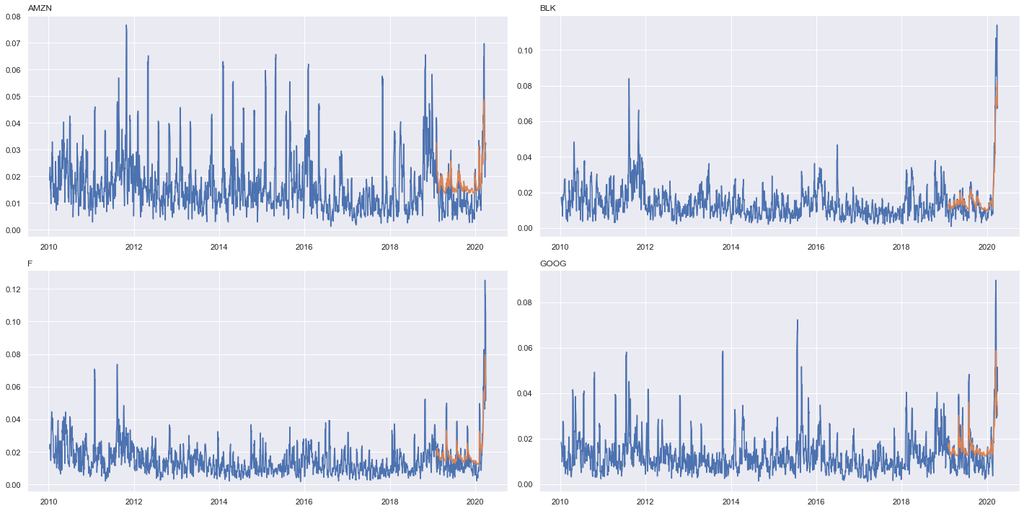

```python
sns.set()
plt.figure(figsize=(20,10))
k=0
for i,j in zip(returns_all.columns,range(len(returns_all.columns))):
    k+=1
    plt.subplot(2,2, k)
    plt.tight_layout()
    plt.plot(rv_all[i]/100)
    plt.plot(np.sqrt(forecast_garch.iloc[:,j])/100)
    plt.title(i, loc='left', fontsize=12)
```

# 4. Volatility Prediction Based on EGARCH Model

At the outset of this lesson, we talked about asymmetry in volatility. Not every event leads to the same volatility, so it is a necessity to capture this volatility asymmetry. `EGARCH` (the exponential generalized autoregressive conditional heteroskedastic) is one of the models that can successfully consider this asymmetry. The equation is rather complex compared to ARCH and GARCH, but we do not need to worry about that. The equation for EGARCH is:

$$\text{log}(h_t)=\omega + \sum^p_{j=1}\beta_j \text{log}(h_{t-j})+ \sum^q_{i=1}\alpha_i\frac{|u_{i-1}|}{\sqrt{h_{t-i}}}+\sum^q_{i=1}\gamma_i\frac{u_{t-i}}{\sqrt{h_{t-i}}} $$

```python
results_egarch=[]
for i in returns_all.columns:
    results_egarch.append(arch_model((returns_all[i]),mean='Constant',vol='egarch',dist='Normal').fit(disp='off'))
```

The result of the EGARCH model is given below:

```python
results_egarch
```

```
[                     Constant Mean - EGARCH Model Results
 ==============================================================================
 Dep. Variable:                   AMZN   R-squared:                      -0.001
 Mean Model:             Constant Mean   Adj. R-squared:                 -0.001
 Vol Model:                     EGARCH   Log-Likelihood:               -5267.06
 Distribution:                  Normal   AIC:                           10542.1
 Method:            Maximum Likelihood   BIC:                           10565.5
                                         No. Observations:                 2578
 Date:                Tue, May 19 2020   Df Residuals:                     2574
 Time:                        11:57:07   Df Model:                            4
                                 Mean Model
 ==========================================================================
                  coef    std err          t      P>|t|    95.0% Conf. Int.
 --------------------------------------------------------------------------
 mu             0.1702  3.985e-02      4.272  1.941e-05 [9.213e-02,  0.248]
                              Volatility Model
 ==========================================================================
                  coef    std err          t      P>|t|    95.0% Conf. Int.
 --------------------------------------------------------------------------
 omega          0.1172  4.475e-02      2.620  8.792e-03 [2.954e-02,  0.205]
 alpha[1]       0.2356  4.854e-02      4.854  1.209e-06   [  0.140,  0.331]
 beta[1]        0.9238  3.034e-02     30.447 1.303e-203   [  0.864,  0.983]
 ==========================================================================

 Covariance estimator: robust
 ARCHModelResult, id: 0x1a2a5a8d68,
                      Constant Mean - EGARCH Model Results
 ==============================================================================
 Dep. Variable:                    BLK   R-squared:                      -0.001
 Mean Model:             Constant Mean   Adj. R-squared:                 -0.001
 Vol Model:                     EGARCH   Log-Likelihood:               -4698.29
 Distribution:                  Normal   AIC:                           9404.59
 Method:            Maximum Likelihood   BIC:                           9428.01
                                         No. Observations:                 2578
 Date:                Tue, May 19 2020   Df Residuals:                     2574
 Time:                        11:57:07   Df Model:                            4
                                 Mean Model
 ==========================================================================
                  coef    std err          t      P>|t|    95.0% Conf. Int.
 --------------------------------------------------------------------------
```

[output cut: 49 more lines]

```
 ===========================================================================
                  coef    std err          t      P>|t|     95.0% Conf. Int.
 ---------------------------------------------------------------------------
 mu             0.0425  3.219e-02      1.319      0.187 [-2.063e-02,  0.106]
                              Volatility Model
 ==========================================================================
                  coef    std err          t      P>|t|    95.0% Conf. Int.
 --------------------------------------------------------------------------
 omega          0.1033  4.724e-02      2.187  2.877e-02 [1.071e-02,  0.196]
 alpha[1]       0.2274  6.682e-02      3.403  6.670e-04 [9.641e-02,  0.358]
 beta[1]        0.9061  4.262e-02     21.258 2.757e-100   [  0.823,  0.990]
 ==========================================================================

 Covariance estimator: robust
 ARCHModelResult, id: 0x1a2a7e1080]
```

```python
forecast_egarch=[]
for i in range(len(returns_all.columns)):
    forecast_egarch.append(results_egarch[i].forecast(start=split_date).variance[split_date:].mean(axis=1))
```

```python
forecast_egarch=pd.DataFrame(forecast_egarch).T
```

```python
forecast_egarch.columns=returns_all.columns
forecast_egarch
```

| Date | AMZN | BLK | F | GOOG |
| --- | --- | --- | --- | --- |
| 2019-02-01 | 8.950982 | 1.849408 | 4.570553 | 3.217101 |
| 2019-02-04 | 7.205506 | 1.629097 | 3.935744 | 3.402210 |
| 2019-02-05 | 6.518778 | 1.438002 | 3.571000 | 3.218062 |
| 2019-02-06 | 5.933473 | 1.321449 | 3.166886 | 3.785343 |
| 2019-02-07 | 5.723448 | 1.233552 | 4.771482 | 3.696448 |
| ... | ... | ... | ... | ... |
| 2020-03-25 | 9.470980 | 48.233237 | 41.826067 | 10.429082 |
| 2020-03-26 | 9.687597 | 53.657931 | 34.102561 | 11.155389 |
| 2020-03-27 | 9.559253 | 46.040519 | 26.903470 | 11.201335 |
| 2020-03-30 | 9.522734 | 40.916579 | 23.381506 | 10.231576 |
| 2020-03-31 | 8.002587 | 35.419750 | 21.494465 | 8.367592 |

293 rows × 4 columns

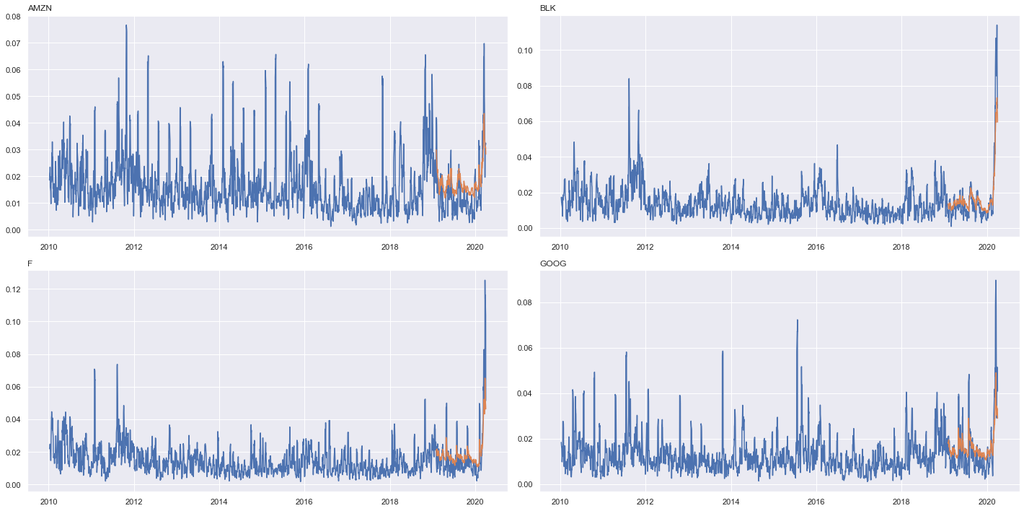

```python
plt.figure(figsize=(20,10))
k=0
for i,j in zip(returns_all.columns,range(len(returns_all.columns))):
    k+=1
    plt.subplot(2,2, k)
    plt.tight_layout()
    plt.plot(rv_all[i]/100)
    plt.plot(np.sqrt(forecast_egarch.iloc[:,j])/100)
    plt.title(i, loc='left', fontsize=12)
```

For those who want to learn more about the `arch_model` package in Python, [see](https://arch.readthedocs.io/en/latest/univariate/introduction.html) this documentation.

# 5. Conclusion

Modeling volatility is of considerable importance in today's highly integrated, turbulent, and sophisticated financial markets. This lesson provides an introduction to the main volatility models. However, as you can imagine, there are many other models that try to improve the deficiencies of the existing models and capture the real-world situation in a better fashion. Next, you should review the Value at Risk and Its Application with Python notebook in this series.

# References

- [Bollerslev, T. (1986). Generalized autoregressive conditional heteroskedasticity. Journal of econometrics, 31(3), 307-327.](http://www.u.arizona.edu/~rlo/readings/278762.pdf)
- [Engle, R. F. (1982). Autoregressive conditional heteroscedasticity with estimates of the variance of United Kingdom inflation. Econometrica: Journal of the Econometric Society, 987-1007.](http://www.econ.uiuc.edu/~econ536/Papers/engle82.pdf)